# Practical Machine Learning Assignment

Loading The required Library Files.

```r
library(caret)
library(parallel)
library(doParallel)
library(randomForest)
```

Loading the Data from the Training Matrix. The dimension is as shown below:

```r
training <- read.csv('pml-training.csv',header=T)
print(dim(training))
```

```
## [1] 19622   160
```

As the data contains many fields with NA and “”, which may not be useful as features while building a predictor, Its important that we get rid of those noises to get a more clean set of data. Below code removes the unnecessary Fields. Dimension after Cleaning the data is as shown :

```r
clean_data <- training[,colSums(is.na(training)) == 0]
clean_data <- clean_data[,colSums(clean_data=="")== 0]
d = dim(clean_data)
```

The dimention of the feature matrix is considerably reduced by the cleaning. For further cleaning, the columns with non-numeric values(except the classe outcome) are ignored as their contribution is not that valuable for prediction purpose.Also the first column is removed as its just the serial numbering , not useful feature for predictions and can influence the decision as data is sorted according to class.

```r
lst = c()
for (i in 1:(d[2]-1))
{
    if(!is.numeric(clean_data[,i]))
    {
        lst = c(lst,i)
    }
}
ndata = clean_data[,-lst]
ndata$X <- NULL
```

Preprocessing(center,scaling) is not required as the chosen model of RandomForest is less Sensible to the scaling of the Features.For selecting a subset of useful features, we can observed the highly correlated features and reduce some of the features accordingly. Final dimentions of feature set is as shown :

```r
correlationMatrix <- cor(ndata[,-56])
highlyCorrelated <- findCorrelation(correlationMatrix, cutoff=0.8)
print(highlyCorrelated)
```

```
##  [1] 13  4 12 39 11 14 24 37 28 22 49 34
```

```r
ndata <- ndata[,-highlyCorrelated[2:length(highlyCorrelated)] ]
print(dim(ndata))
```

```
## [1] 19622    45
```

The learning model is chosen as Random Forest as its less prone to overfitting the data, Implicit **bagging and cross validation** is there as the best model is chosen considering the error rate in the **Out-Of-Bag(OOB) samples**. Explicit resampling and Cross Validation is not required thus.

```r
cl <- makeCluster(detectCores() - 1)
registerDoParallel(cl, cores = detectCores() - 1)
#train_control <- trainControl(method="cv", number=10)
model = randomForest(classe ~.,data=ndata)
stopCluster(cl)
print(model)
```

```
##
## Call:
##  randomForest(formula = classe ~ ., data = ndata)
##                Type of random forest: classification
##                      Number of trees: 500
## No. of variables tried at each split: 6
##
##         OOB estimate of  error rate: 0.06%
## Confusion matrix:
##      A    B    C    D    E  class.error
## A 5580    0    0    0    0 0.0000000000
## B    2 3795    0    0    0 0.0005267316
## C    0    5 3417    0    0 0.0014611338
## D    0    0    2 3213    1 0.0009328358
## E    0    0    0    1 3606 0.0002772387
```

```r
print(varImp(model))
```

```
##                         Overall
## raw_timestamp_part_1 2202.59096
## raw_timestamp_part_2   22.88732
## num_window           1341.37155
## pitch_belt            746.76575
## yaw_belt              901.48363
## total_accel_belt      290.95246
## gyros_belt_x           99.46878
## gyros_belt_y          129.73410
## gyros_belt_z          351.52531
## accel_belt_z          428.54577
## magnet_belt_y         450.92859
## magnet_belt_z         423.55722
## roll_arm              282.35101
## pitch_arm             143.62715
## yaw_arm               219.63464
## total_accel_arm        88.29526
## gyros_arm_x           110.72158
## gyros_arm_z            46.50040
## accel_arm_y           136.85167
## accel_arm_z            94.32365
## magnet_arm_x          280.37101
## magnet_arm_z          138.72646
## roll_dumbbell         383.84718
## pitch_dumbbell        191.72592
## yaw_dumbbell          287.56597
## total_accel_dumbbell  310.37658
## gyros_dumbbell_y      190.91940
## gyros_dumbbell_z       62.61548
## accel_dumbbell_y      415.98952
## magnet_dumbbell_x     476.49784
## magnet_dumbbell_y     662.85221
## magnet_dumbbell_z     734.32508
## roll_forearm          533.46814
## pitch_forearm         756.18993
## yaw_forearm           144.14674
## total_accel_forearm    84.17432
## gyros_forearm_x        61.93672
## gyros_forearm_y        92.77992
## accel_forearm_x       282.75321
## accel_forearm_y       109.70181
## accel_forearm_z       229.78263
## magnet_forearm_x      178.21974
## magnet_forearm_y      165.31807
## magnet_forearm_z      225.88784
```

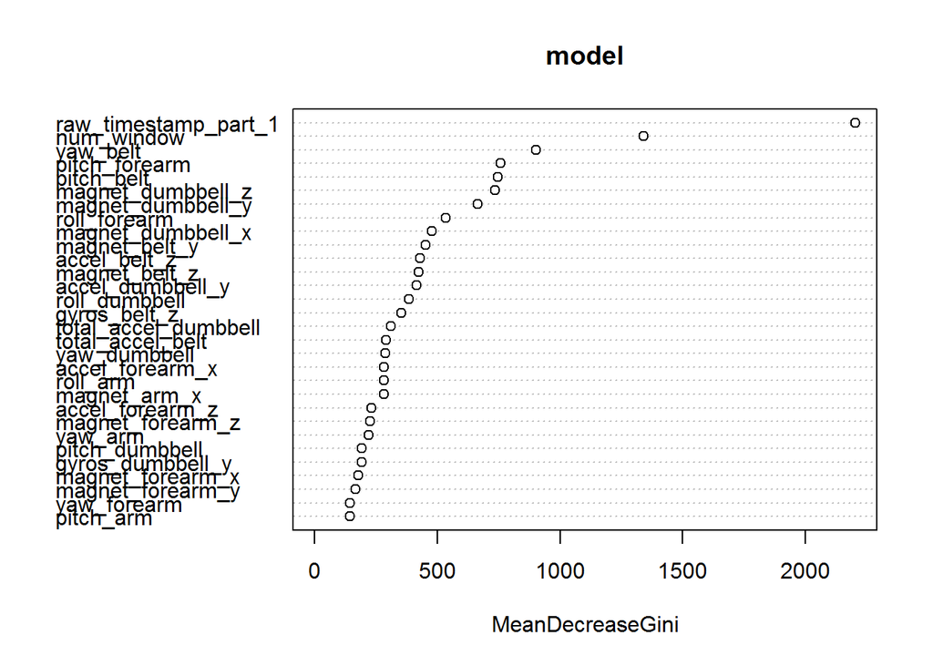

```r
varImpPlot(model)
```

Testing is to be done on the separate test cases. The outcome is as below:

```r
testing <- read.csv('pml-testing.csv',header = T)
predi = predict(model,newdata = testing)
print(predi)
```

```
##  1  2  3  4  5  6  7  8  9 10 11 12 13 14 15 16 17 18 19 20
##  B  A  B  A  A  E  D  B  A  A  B  C  B  A  E  E  A  B  B  B
## Levels: A B C D E
```